# Cardio Good Fitness Project -FS

Loading the libraries

```python
import warnings
warnings.filterwarnings('ignore')
```

```python
import pandas as pd
import numpy as np
import seaborn as sns
sns.set_style('darkgrid')
import matplotlib.pyplot as plt
%matplotlib inline
#import warnings
pd.set_option('display.float_format', lambda x: '%.5f' % x) # To supress numerical display in scientific notations
```

Import the dataset

```python
data=pd.read_csv('CardioGoodFitness.csv')
prod=data['Product']
age=data['Age']
gender=data['Gender']
status=data['MaritalStatus']
```

Check if the data has any missing values. Some plots will not work in the presence of missing values.

```python
prod.isnull().sum()
```

```
0
```

Check the data head()

```python
data.head()
```

|  | Product | Age | Gender | Education | MaritalStatus | Usage | Fitness | Income | Miles |
| --- | --- | --- | --- | --- | --- | --- | --- | --- | --- |
| 0 | TM195 | 18 | Male | 14 | Single | 3 | 4 | 29562 | 112 |
| 1 | TM195 | 19 | Male | 15 | Single | 2 | 3 | 31836 | 75 |
| 2 | TM195 | 19 | Female | 14 | Partnered | 4 | 3 | 30699 | 66 |
| 3 | TM195 | 19 | Male | 12 | Single | 3 | 3 | 32973 | 85 |
| 4 | TM195 | 20 | Male | 13 | Partnered | 4 | 2 | 35247 | 47 |

Univariate Analysis - plots histogram

- bin argument is class intervals ,x axis -observations and y axis-frequency of occurance of observations

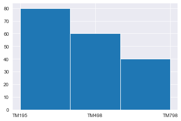

```python
plt.hist(prod,bins=3)
```

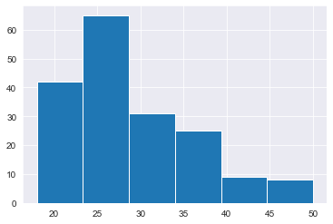

```python
plt.hist(age,bins=6)
```

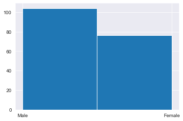

```python
plt.hist(gender,bins=2)
```

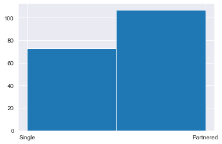

```python
plt.hist(status,bins=2)
```

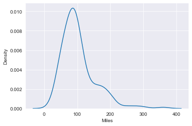

```python
sns.distplot(data['Miles'],hist=False)
```

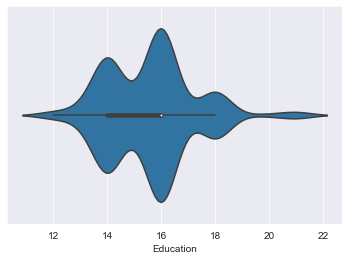

```python
sns.violinplot(data['Education'])
```

**The violin plot function from seaborn. The violin plot shows a vertical mirror image of the distribution along with the original distribution.**

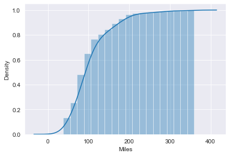

```python
sns.distplot(data['Miles'],hist_kws=dict(cumulative=True),kde_kws=dict(cumulative=True))
```

```python
data.describe()
```

|  | Age | Education | Usage | Fitness | Income | Miles |
| --- | --- | --- | --- | --- | --- | --- |
| count | 180.00000 | 180.00000 | 180.00000 | 180.00000 | 180.00000 | 180.00000 |
| mean | 28.78889 | 15.57222 | 3.45556 | 3.31111 | 53719.57778 | 103.19444 |
| std | 6.94350 | 1.61705 | 1.08480 | 0.95887 | 16506.68423 | 51.86360 |
| min | 18.00000 | 12.00000 | 2.00000 | 1.00000 | 29562.00000 | 21.00000 |
| 25% | 24.00000 | 14.00000 | 3.00000 | 3.00000 | 44058.75000 | 66.00000 |
| 50% | 26.00000 | 16.00000 | 3.00000 | 3.00000 | 50596.50000 | 94.00000 |
| 75% | 33.00000 | 16.00000 | 4.00000 | 4.00000 | 58668.00000 | 114.75000 |
| max | 50.00000 | 21.00000 | 7.00000 | 5.00000 | 104581.00000 | 360.00000 |

Check the columns

```python
data.columns
```

```
Index(['Product', 'Age', 'Gender', 'Education', 'MaritalStatus', 'Usage',
       'Fitness', 'Income', 'Miles'],
      dtype='object')
```

```python
data.shape
```

```
(180, 9)
```

```python
data.dtypes.value_counts()
```

```
int64     6
object    3
dtype: int64
```

```python
data.info()
```

```
<class 'pandas.core.frame.DataFrame'>
RangeIndex: 180 entries, 0 to 179
Data columns (total 9 columns):
 #   Column         Non-Null Count  Dtype
---  ------         --------------  -----
 0   Product        180 non-null    object
 1   Age            180 non-null    int64
 2   Gender         180 non-null    object
 3   Education      180 non-null    int64
 4   MaritalStatus  180 non-null    object
 5   Usage          180 non-null    int64
 6   Fitness        180 non-null    int64
 7   Income         180 non-null    int64
 8   Miles          180 non-null    int64
dtypes: int64(6), object(3)
memory usage: 12.8+ KB
```

```python
data[['Education','Usage','Fitness','Income','Miles']].describe() #descriptive stats of continuous columns
```

|  | Education | Usage | Fitness | Income | Miles |
| --- | --- | --- | --- | --- | --- |
| count | 180.00000 | 180.00000 | 180.00000 | 180.00000 | 180.00000 |
| mean | 15.57222 | 3.45556 | 3.31111 | 53719.57778 | 103.19444 |
| std | 1.61705 | 1.08480 | 0.95887 | 16506.68423 | 51.86360 |
| min | 12.00000 | 2.00000 | 1.00000 | 29562.00000 | 21.00000 |
| 25% | 14.00000 | 3.00000 | 3.00000 | 44058.75000 | 66.00000 |
| 50% | 16.00000 | 3.00000 | 3.00000 | 50596.50000 | 94.00000 |
| 75% | 16.00000 | 4.00000 | 4.00000 | 58668.00000 | 114.75000 |
| max | 21.00000 | 7.00000 | 5.00000 | 104581.00000 | 360.00000 |

```python
my_tab = pd.crosstab(index=data["Age"],  # Make a crosstab
                     columns="count")                  # Name the count column
my_tab
```

| col_0 Age | count |
| --- | --- |
| 18 | 1 |
| 19 | 4 |
| 20 | 5 |
| 21 | 7 |
| 22 | 7 |
| 23 | 18 |
| 24 | 12 |
| 25 | 25 |
| 26 | 12 |
| 27 | 7 |
| 28 | 9 |
| 29 | 6 |
| 30 | 7 |
| 31 | 6 |
| 32 | 4 |
| 33 | 8 |
| 34 | 6 |
| 35 | 8 |
| 36 | 1 |
| 37 | 2 |
| 38 | 7 |
| 39 | 1 |
| 40 | 5 |
| 41 | 1 |
| 42 | 1 |
| 43 | 1 |
| 44 | 1 |
| 45 | 2 |
| 46 | 1 |
| 47 | 2 |
| 48 | 2 |
| 50 | 1 |

```python
def missing_check(data):
    total = data.isnull().sum().sort_values(ascending=False)   # total number of null values
    percent = (data.isnull().sum()/data.isnull().count()).sort_values(ascending=False)  # percentage of values that are null
    missing_data = pd.concat([total, percent], axis=1, keys=['Total', 'Percent'])  # putting the above two together
    return missing_data # return the dataframe
missing_check(data)
```

|  | Total | Percent |
| --- | --- | --- |
| Product | 0 | 0.00000 |
| Age | 0 | 0.00000 |
| Gender | 0 | 0.00000 |
| Education | 0 | 0.00000 |
| MaritalStatus | 0 | 0.00000 |
| Usage | 0 | 0.00000 |
| Fitness | 0 | 0.00000 |
| Income | 0 | 0.00000 |
| Miles | 0 | 0.00000 |

```
array([[<AxesSubplot:title={'center':'Age'}>,
        <AxesSubplot:title={'center':'Education'}>],
       [<AxesSubplot:title={'center':'Usage'}>,
        <AxesSubplot:title={'center':'Fitness'}>],
       [<AxesSubplot:title={'center':'Income'}>,
        <AxesSubplot:title={'center':'Miles'}>]], dtype=object)
```

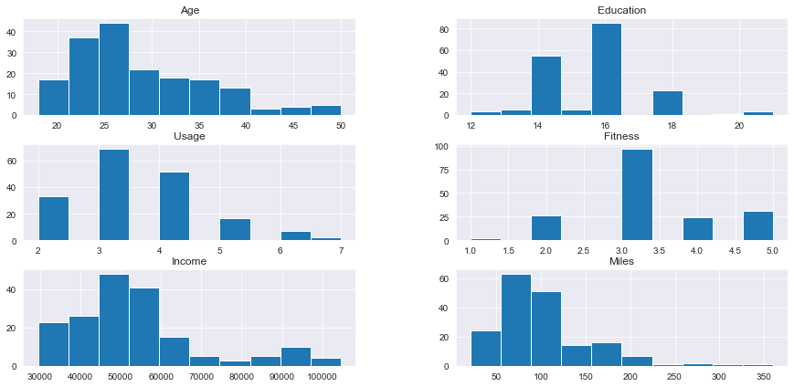

```python
data.hist(figsize=(15,7))
```

[figure not shown]

```python
plt.hist(data, bins=7)
```

Multivariate analysis

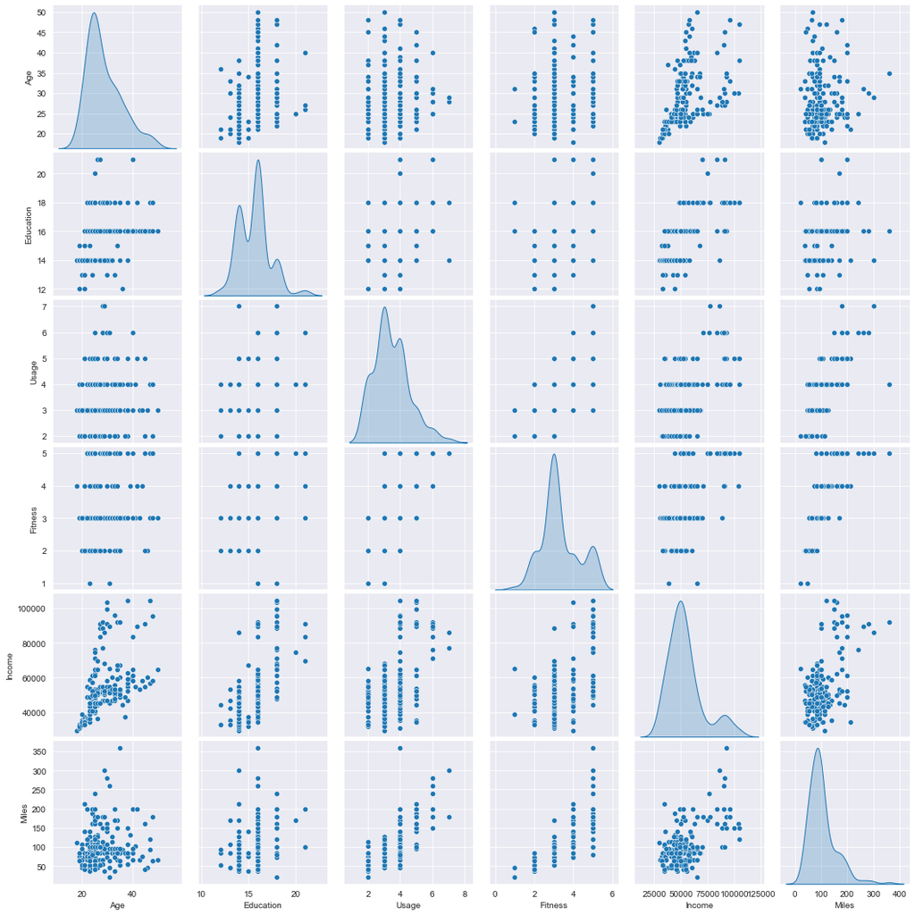

```python
sns.pairplot(data, diag_kind="kde")
```

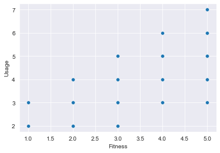

```python
sns.scatterplot(data['Fitness'],data['Usage'])
```

```python
data.corr()
```

|  | Age | Education | Usage | Fitness | Income | Miles |
| --- | --- | --- | --- | --- | --- | --- |
| Age | 1.00000 | 0.28050 | 0.01506 | 0.06110 | 0.51341 | 0.03662 |
| Education | 0.28050 | 1.00000 | 0.39516 | 0.41058 | 0.62583 | 0.30728 |
| Usage | 0.01506 | 0.39516 | 1.00000 | 0.66861 | 0.51954 | 0.75913 |
| Fitness | 0.06110 | 0.41058 | 0.66861 | 1.00000 | 0.53501 | 0.78570 |
| Income | 0.51341 | 0.62583 | 0.51954 | 0.53501 | 1.00000 | 0.54347 |
| Miles | 0.03662 | 0.30728 | 0.75913 | 0.78570 | 0.54347 | 1.00000 |

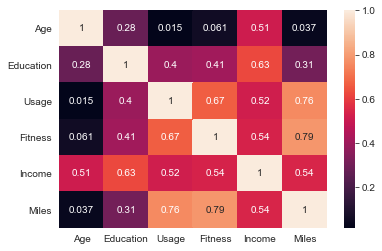

```python
sns.heatmap(data.corr(), annot=True)  # plot the correlation coefficients as a heatmap
```

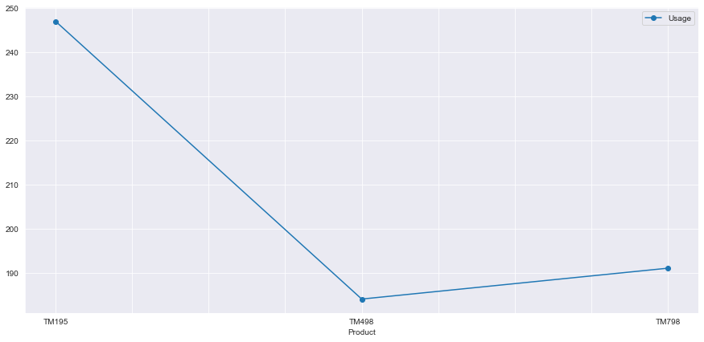

```python
data.groupby('Product')[['Usage']].sum().plot(figsize=(15,7), style='o-')
```

- Usage is high for the product TM195 compared to other products.

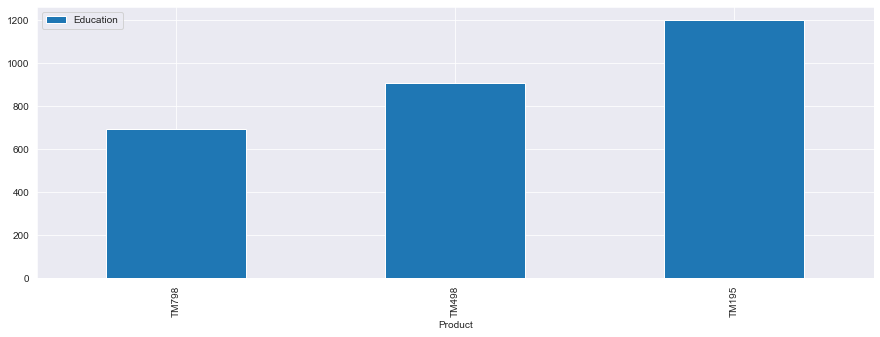

```python
data.groupby(by=['Product'])['Education'].sum().reset_index().sort_values(['Education'],
                    ascending=True).head(10).plot(x='Product',y='Education',kind='bar', figsize=(15,5))

plt.show()
```

Average Usage across each Product for a given gender along with the confidence intervals - Point Plot

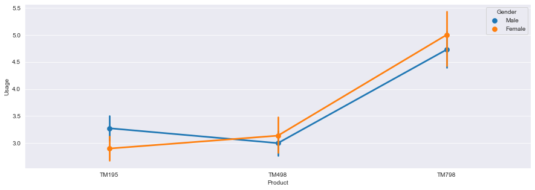

```python
plt.figure(figsize=(15,5))
sns.pointplot(x="Product", y="Usage", hue = 'Gender',  data=data)
plt.show()
```

- TM195 Product usage distribution is high for Males.

Scatter plot Age Vs Income

# This is an examples of Numerical vs. Numerical

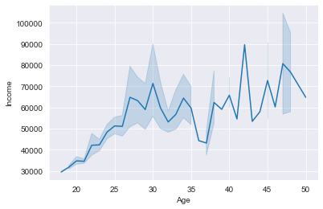

```python
#Here we plotting a line plot.
sns.lineplot(x='Age',y='Income', data=data )
```

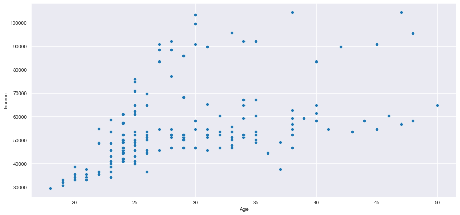

```python
figure = plt.figure(figsize=(15,7))

sns.scatterplot(x='Age', y='Income', data=data) # scatter plot
plt.show()
```

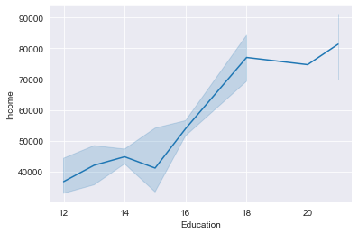

```python
#Here we plotting a line plot.
sns.lineplot(x='Education',y='Income', data=data )
```

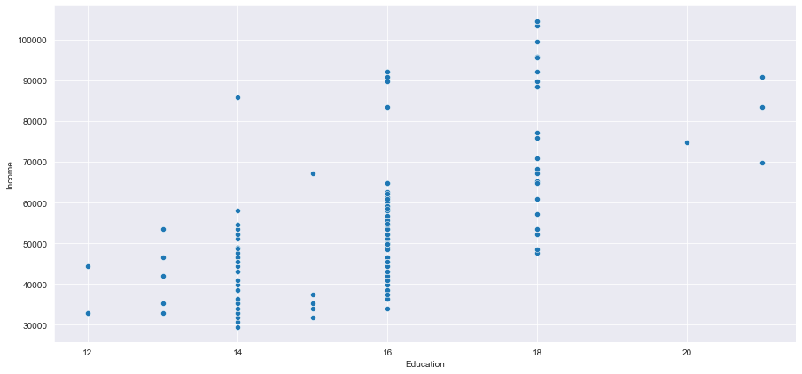

```python
figure = plt.figure(figsize=(15,7))

sns.scatterplot(x='Education', y='Income', data=data) # scatter plot
plt.show()
```

- Looks like with Education 18 a bit more prevalent with higher Income.

Bar plot To check Product by Fitness

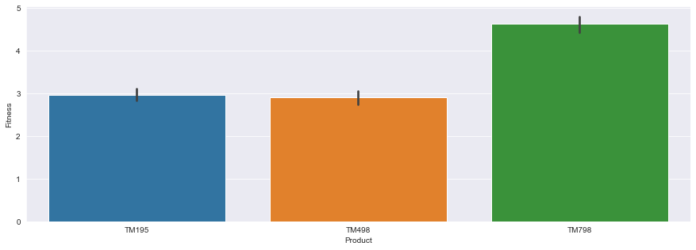

```python
plt.figure(figsize=(15,5))
sns.barplot(data=data,x='Product',y='Fitness')
plt.show()
```

- High fitness customers prefer product TM798

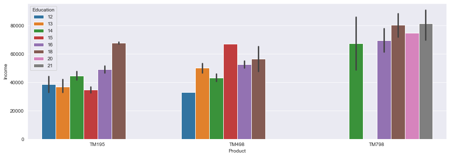

```python
plt.figure(figsize=(15,5))
sns.barplot(data=data,x='Product',y='Income',hue='Education')
plt.show()
```

- Higher income and high educated people using product TM798.
- Education of 12,13 and 15 people are not using product TM798.
- Highest educated of 21 people are not using product TM195 and TM498.

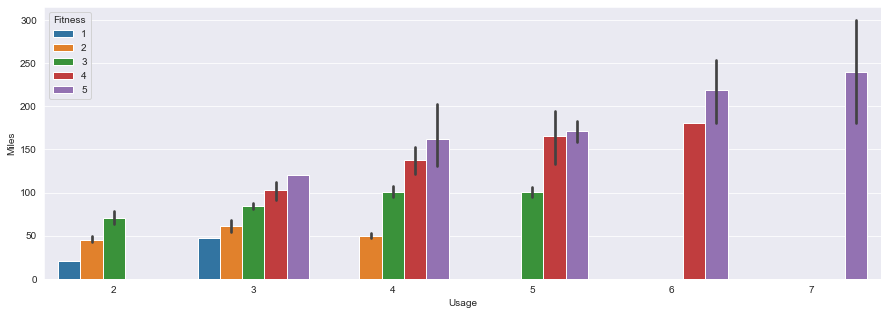

```python
plt.figure(figsize=(15,5))
sns.barplot(data=data,x='Usage',y='Miles',hue='Fitness')
plt.show()
```

- highest usage have the highest fitness and highest miles.
- when usage is increasing Fitness also increasing.

Pandas Profiling

```python
import pandas_profiling
```

```python
auto=pd.read_csv('CardioGoodFitness.csv')
```

```python
pandas_profiling.ProfileReport(auto)
```

[interactive chart not shown]

Conclusion

- When Customers usage is high their Fitness also high.Miles also high for these customers.
- Higher income and high educated Customers using product TM798.
- Customers with Education of 12,13 and 15 are not using product TM798.
- Customers with highest education[ 21] are not using product TM195 and TM498.
- High fitness customers prefer product TM798
- TM195 Product usage distribution is high for Males.